# Project 1

Isaac Beaumont

2024-01-22

```r
f_0 <- function(x, a_0){
    return(a_0)
}
f_1 <- function(x, a_0, a_1){
    return(a_0 + a_1 * x)
}
f_2 <- function(x, a_0, a_1, a_2){
    return(a_0 + a_1 * x + a_2 * x^2)
}
f_3 <- function(x, a_0, a_1, a_2){
    return(a_0 + a_1 * exp(-a_2 * x))
}
f_4 <- function(x, a_0, a_1, a_2){
    return(a_0 + a_1 * x + a_2)
}
f_5 <- function(x, a_0, a_1, a_2){
    return((a_0 + a_1 * x) * exp(-a_2 * x))
}
```

# Task 2

**I decided to evaluate all the functions but will only graph 2 of them. Namely f_3(x) & f_5(x).**

## Functions

### Function 3

The equation of $f_3(x)$ is as follows $f_3(x; a_0, a_1, a_2) = a_0 + a_1 * e^{-a_2 * x}$. This type of equation is commonly used for exponential decay of items. As such I will refer to the graph components in the context of decay.

$x$ is the input variable so as that number changes movement across the x-axis changes at the same rate, unless altered by other variables.

$a_0$ is a constant. As this number changes it changes the y asymptote of the graph. Negative values drop the y asymptote. Positive values drive it up.

$a_1$ is a constant. As this number changes it will affect the degree or magnitude of the decay.

$a_2$ is a constant. As this number changes it affects the rate at which the variables or object decays.

### Function 4

The equation of $f_4(x)$ is as follows $f_4(x; a_0, a_1, a_2) = a_0 + a_1 * x + a_2$

$x$ is the input variable so as that number changes movement across the x-axis changes at the same rate

$a_0$ & $a_2$ are constants. These affect the vertical shift of the graph. As the values increase so does the vertical or y-intercept. They work together, and yet work seprately (they can be their own unique values) Thus making it so they affect the value together. In Linear Regression $a_2$ is commonly used with an $x_{2i}$ in order to turn a_2 into a variable to create a seperate line. However, as this does not exist they work in tandem.

$a_1$ is a constant that affects the slope or steepness of the line.

### Function 5

The equation of $f_5(x)$ is as follows $f_5(x; a_0, a_1, a_2) = (a_0 + a_1 * x) * e^{-a_2 * x}$

$x$ is the input variable so as that number changes movement across the x-axis changes at the same rate. It also is put into the decay rate affecting the speed with $-a_2$

$a_0$ and $a_1$ create the linear part of the equation. $a_0$ controls the intercept. $a_1$ controls the slope and steepness of that line.

$a_2$ however, influences the exponential decay rate with $x$

## Graphs

**Here is the parameter values used in the graph**

`Note: The 1st value is the blue line the 2nd is the red`

*a0_values <- c(1, 2)*

*a1_values <- c(2, 4)*

`Note: This creates a vector from 0 to 30 incrementing by 0.5`

*x <- seq(0, 30, .5)*

`Note: Creation of y values for respective functions`

*y_3 <- f_3(x, a0_values, a1_values, a2_values)*

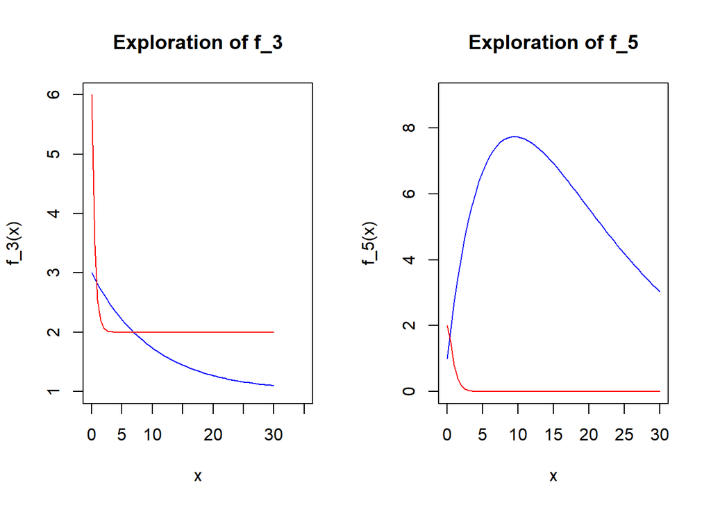

```r
a0_values <- c(1, 2)
a1_values <- c(2, 4)
a2_values <- c(0.1, 2)
x <- seq(0, 30, .5)
y_3 <- f_3(x, a0_values, a1_values, a2_values)
y_4 <- f_5(x, a0_values, a1_values, a2_values)

par(mfrow = c(1, 2))

# Plot for f_3
plot(x, f_3(x, a0_values[1], a1_values[1], a2_values[1]), type = "l", col = "blue", ylab = "f_3(x)", main = "Exploration of f_3", ylim = c(1, 6), xlim = c(0, 35))
lines(x, f_3(x, a0_values[2], a1_values[2], a2_values[2]), col = "red")

# Plot for f_5
plot(x, f_5(x, a0_values[1], a1_values[1], a2_values[1]), type = "l", col = "blue", ylab = "f_5(x)", main = "Exploration of f_5", xlim = c(0, 30), ylim = c(0, 9))
lines(x, f_5(x, a0_values[2], a1_values[2], a2_values[2]), col = "red")
```

```r
par(mfrow = c(1, 1))
```

As is stated above the graphs rendered show the values for $f_3(x)$ and $f_5x$. Each of the values.

In the first graph $a_0$ affects the asymptote of the graph. $a_1$ affects the start location of the trend. $a_2$ will affect the steepness of the trend.